# IS-LM

Dr. J

3/8/2020

# IS-LM model, Simplified Keynesian

Data Analytics MGMT 6550

Data are quarterly, Jan 2017 to Oct 2019  
all dollar amounts are billions  
all data from ‘FRED’ Federal Reserve bank St. Louis

Actual data from the past 3 years. Can this provide insight into economic policy? Specifically the COVID19 virus will have exogenous effects on the US economy, what policies (fiscal/monetary) would serve to minimize the effect of decreased production and trade?

## set up data

```r
ISLMdata = data.frame(

  # consumpton
  Consum = c(13104.43333, 13212.5, 13345.06667,
             13586.26667, 13728.33333, 13939.83333,
             14114.53333, 14211.9, 14266.26667,
             14511.16667, 14678.2, 14789.26667),

  # GDP, aggregate demand
  Y = c(19190.431, 19356.649, 19611.704, 19918.91,
        20163.159, 20510.177, 20749.752, 20897.804,
        21098.827, 21340.267, 21542.54,  21726.779),

  # Government spending
  G_spend = c(6526.927, 6525.904, 6623.281, 6713.611,
              6806.73, 6901.58, 6971.018, 7042.209,
              7149.65, 7292.506, 7359.535, 7424.398),

  # Gross domestic savings
  personalSavings = c(3600.665, 3613.782, 3658.564, 3632.806,
                      3826.156, 3753.84, 3814.944, 3785.88,
                      3909.787, 3866.799, 3826.739, 3840.0),

  # M1 money supply, cash and checking deposits
  M1 = c(3405.461538, 3498.1, 3570.161538, 3613.338462,
         3639.484615, 3658.723077, 3688.038462,
         3719.442857, 3743.891667, 3796.215385,
         3867.964286, 3950.738462),

  # M2 money supply  M1 + easily convertible
  M2 = c(13332.09231, 13515.83846, 13659.85385,
         13794.4, 13892.84615, 14045.68462,
         14186.1, 14275.91429, 14464.79167,
         14645.46154, 14932.30714, 15243.2),

  # Government revenue
  Taxes = c(1987.626, 2003.74, 2042.913, 2042.372,
            1921.492, 1943.529, 1971.38, 1987.923,
            2018.649, 2027.559, 2028.389, 2030.0 ),


  # velocity of money; how many times $ changes hands
  Vel_M1 = c(5.623, 5.529, 5.493, 5.513, 5.534,
             5.605, 5.625, 5.616, 5.636, 5.613,
             5.564, 5.5),

  # net exports $ value of exports - imports
  Nx = c(-570.922, -583.726, -550.586, -596.11,
         -628.967, -568.391, -671.353, -684.148,
         -633.848, -662.66,  -653.032, -577.381),

  # consumer price index
  CPI = c(243.822, 244.0543333, 245.359, 247.25,
          249.2346667, 250.591, 251.8826667,
          252.6973333, 253.2753333, 255.1706667,
          256.3246667, 257.8323333),

  # interest rate, %
  fedRate = c(0.7,0.95, 1.153, 1.203, 1.446, 1.737,
              1.923, 2.22, 2.403, 2.397, 2.19, 1.643),
  # libor %
  libor=c(0.829557031, 1.06296541, 1.231578281,
          1.330114127, 1.653367302, 1.971670645,
          2.107461406, 2.34698, 2.49826381,
          2.442525738, 2.178625385, 1.791037656 ),

  # investment
  Invest = c(3140.293, 3167.926, 3225.247, 3262.117,
             3311.826, 3296.571, 3404.226, 3429.477,
             3481.088, 3424.653, 3416.18,  3363.567 )
)
```

Get price index, M/P, set interestRate

```r
pIndex = ISLMdata$CPI/ISLMdata$CPI[1] # normalize CPI

# constant $ money supply Gross $$ divided by P
MoverP = ISLMdata$M1/pIndex

ISLMdata$'MoverP'= MoverP

interestRate = ISLMdata$libor

attach(ISLMdata)
```

## Equations:

descriptions: Economic goals  
Full Employment GDP is estimated to be $21700B interest rate aroud 1%

### LM - liquidity preference for money

M/P = M0 + m1 $\times$ Y + m2 $\times$ interest

### IS curve:

Y = (C0 + b $\times$ (Y-Tax) + I0 + dY $\times$ Y +dInt $\times$ interest + G - Nx )  
write two IS functions:  
IS_Y, solve for y in the IS equation  
IS_i, solve for interest in the IS equation

### LM curve:

write two LM functions:  
LM_Y, solve for Y in the M/P equation  
LM_i, solve for i in the M/P equation

## Quesions:

1. Given the last values of the variables, (estimates of current US macroeconomic values)
1. What is the equilibrium level of GDP predicted by IS_Y?
2. If these are difference from the present levels, for example if predicted GDP exceeds full employment GDP or interest rate is negative,  
   what does this model suggest about the US economy?
2. Policy- the COVID19 virus will likely reduce GDP by 1 or 2 % and change Nx by about 5%-10% (we import less). Given this, What policy measures does the IS-LM model suggest as a way to maintain GDP?

## FUNCTIONS ————————————————–

## consumption function

consumption is a function of disposable income, (Y - tax)

```r
disposableY = Y-Taxes
consumpFcn=glm(Consum ~ disposableY) # Y-Taxes is disposable income
summary(consumpFcn)
```

```
##
## Call:
## glm(formula = Consum ~ disposableY)
##
## Deviance Residuals:
##    Min      1Q  Median      3Q     Max
## -70.23  -29.36   12.01   27.13   53.88
##
## Coefficients:
##              Estimate Std. Error t value Pr(>|t|)
## (Intercept) 1.682e+03  2.902e+02   5.795 0.000174 ***
## disposableY 6.632e-01  1.567e-02  42.335  1.3e-12 ***
## ---
## Signif. codes:  0 '***' 0.001 '**' 0.01 '*' 0.05 '.' 0.1 ' ' 1
##
## (Dispersion parameter for gaussian family taken to be 1970.338)
##
##     Null deviance: 3550972  on 11  degrees of freedom
## Residual deviance:   19703  on 10  degrees of freedom
## AIC: 128.9
##
## Number of Fisher Scoring iterations: 2
```

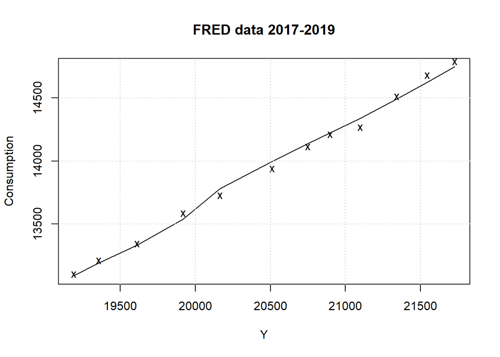

```r
#get the coefficients for later use
C0 = as.numeric(consumpFcn$coefficients[1])
b = as.numeric(consumpFcn$coefficients[2])

consumption=function(Y, Taxes, C0, b){
  disposableY = Y-Taxes
  return(C0+b*disposableY)
}

plot(Y, consumption(Y, Taxes, C0, b), ylab='Consumption', type  = 'l',main='FRED data 2017-2019')
points(Y,Consum, pch='x')
grid()
```

## investment function

```r
investFcn = glm(Invest ~ Y + interestRate)
summary(investFcn)
```

```
##
## Call:
## glm(formula = Invest ~ Y + interestRate)
##
## Deviance Residuals:
##     Min       1Q   Median       3Q      Max
## -58.574   -6.040    3.602   16.755   28.765
##
## Coefficients:
##               Estimate Std. Error t value Pr(>|t|)
## (Intercept)  2.468e+03  3.319e+02   7.437 3.94e-05 ***
## Y            2.858e-02  1.819e-02   1.571 0.150742
## interestRate 1.526e+02  2.768e+01   5.512 0.000374 ***
## ---
## Signif. codes:  0 '***' 0.001 '**' 0.01 '*' 0.05 '.' 0.1 ' ' 1
##
## (Dispersion parameter for gaussian family taken to be 718.763)
##
##     Null deviance: 134918.5  on 11  degrees of freedom
## Residual deviance:   6468.9  on  9  degrees of freedom
## AIC: 117.53
##
## Number of Fisher Scoring iterations: 2
```

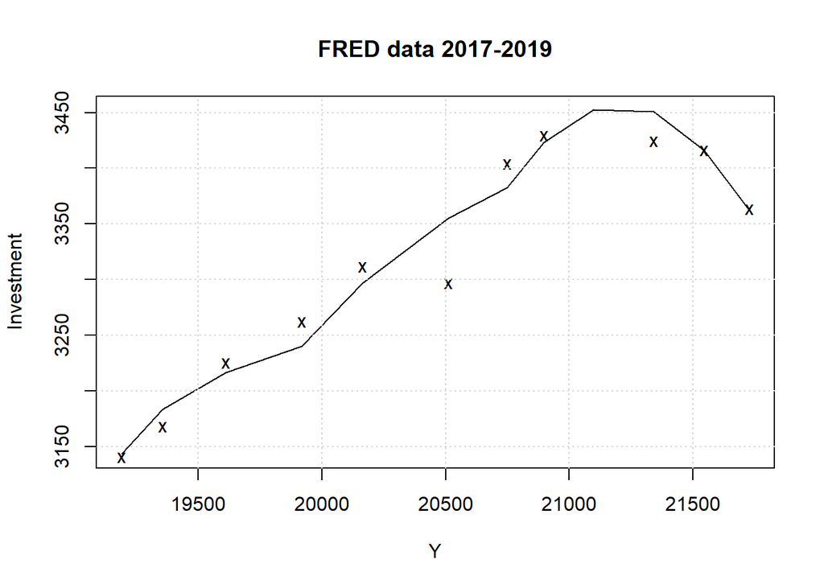

```r
I0 = as.numeric(investFcn$coefficients[1])
dY = as.numeric(investFcn$coefficients[2])
dInt = as.numeric(investFcn$coefficients[3])

investment = function(Y, interestRate){
  return(I0 + dY*Y +dInt*interestRate)
}

plot(Y, investment(Y, interestRate), type='l',main='FRED data 2017-2019', ylab = 'Investment')
points(Y,Invest, pch='x')
grid()
```

## demand for money function

```r
moneyFcn = glm(MoverP ~ Y + interestRate)
summary(moneyFcn)
```

```
##
## Call:
## glm(formula = MoverP ~ Y + interestRate)
##
## Deviance Residuals:
##     Min       1Q   Median       3Q      Max
## -70.313   -7.403   -0.755   14.528   45.793
##
## Coefficients:
##                Estimate Std. Error t value Pr(>|t|)
## (Intercept)  1104.18785  388.22776   2.844 0.019271 *
## Y               0.12649    0.02128   5.943 0.000217 ***
## interestRate  -67.30521   32.38612  -2.078 0.067460 .
## ---
## Signif. codes:  0 '***' 0.001 '**' 0.01 '*' 0.05 '.' 0.1 ' ' 1
##
## (Dispersion parameter for gaussian family taken to be 983.6249)
##
##     Null deviance: 77009.6  on 11  degrees of freedom
## Residual deviance:  8852.6  on  9  degrees of freedom
## AIC: 121.3
##
## Number of Fisher Scoring iterations: 2
```

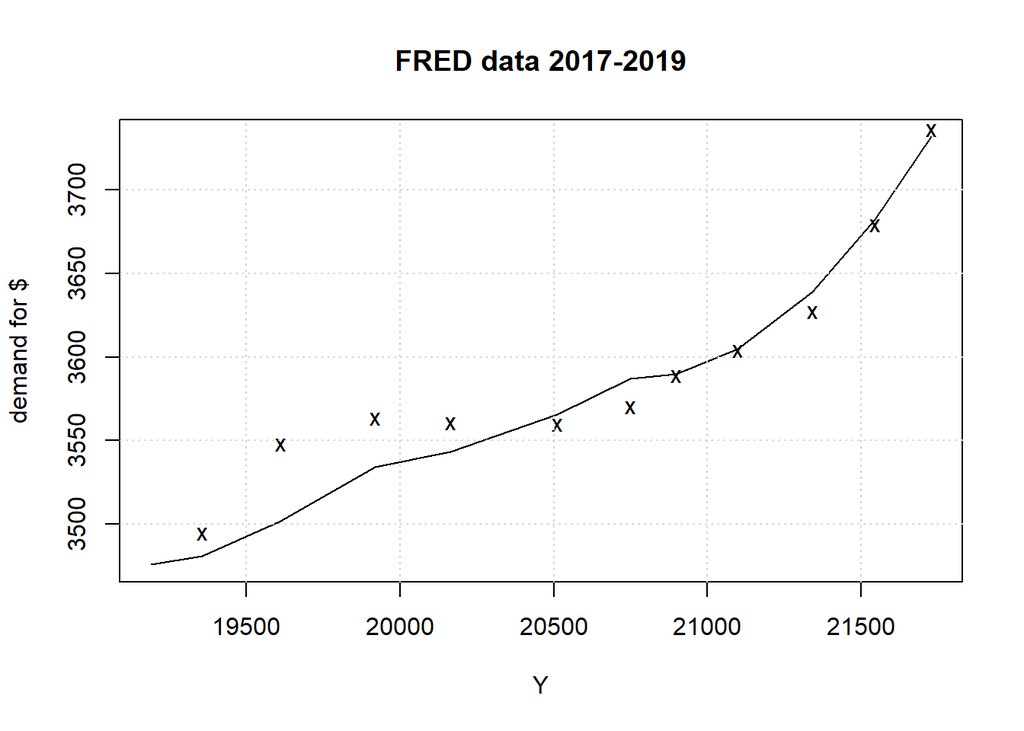

```r
M0 = moneyFcn$coefficients[1]
m1 = moneyFcn$coefficients[2]
m2 = moneyFcn$coefficients[3]

demandM = function(Y, Int_R, M0, m1, m2){
  return( M0 + m1*Y + m2*Int_R)
}

plot(Y, demandM(Y, interestRate, M0, m1, m2), type='l', ylab = 'demand for $', main='FRED data 2017-2019')
points(Y, MoverP, pch='x')
grid()
```

## IS -

Innvestment/saving formula from in class

Y from IS equation

```r
IS_Y = function(C0, b, I0, dY, dInt, intRate, tax, G, Nx){
  # C0, b:  coefficients from consumption function
  # I0, dY, dInt: coefficients from investment function
  # intRate:  interest rate
  # Tax, G, Nx: government spending, net exports, exogenous
  Y = (C0-b*tax  + I0 + dInt*intRate + G - Nx)/(1-dY-b)
  return(Y)
}
```

```r
IS_i = function(Y, C, I0, dY, dInt, G, Nx){
  intR = (Y -C -I0 -dY*Y-G +Nx)/dInt
  return(intR)
}
```

## LM

interest from LM

```r
LM_i = function(MoverP,Y, M0, m1, m2){
  intR = (MoverP - M0 - m1*Y)/m2
  return(as.numeric(intR))
}
```

GDP from LM

```r
LM_Y = function(MoverP,intR, M0, m1, m2){
  Y = (MoverP-m2*intR)/m1
  return(Y)
}
```

### 1. find values of Tax and g_sPend the result in interestRate around 1% Using IS

```r
#Macro economic targets these are fixed----
Y_FE = 21700 #Full Employment GDP
netX =-450
intR = 1.0
#------------------------------------------

#Fiscal policy--  YOU adjust these
Tax = 2000
g_Spend = 7500

#Monetary policy--  YOU set this
mOp = 3950 # money supply

#-------------------------------------------------------

C = consumption(Y_FE, Tax, C0, b)
print(paste('consumption: ',C))
```

```
## [1] "consumption:  14747.5754793308"
```

```r
I = investment(Y_FE, intR)
print(paste('investment: ',I))
```

```
## [1] "investment:  3240.86989354311"
```

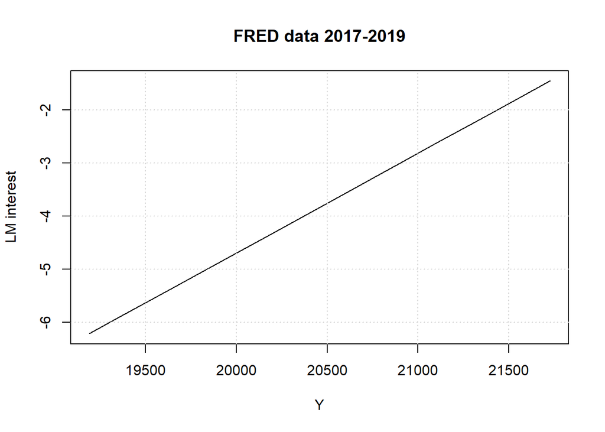

```r
equilibIntRate=LM_i(mOp,Y, M0, m1, m2)
plot(Y,equilibIntRate, ylab = 'LM interest', type='l',main='FRED data 2017-2019')
grid()
```

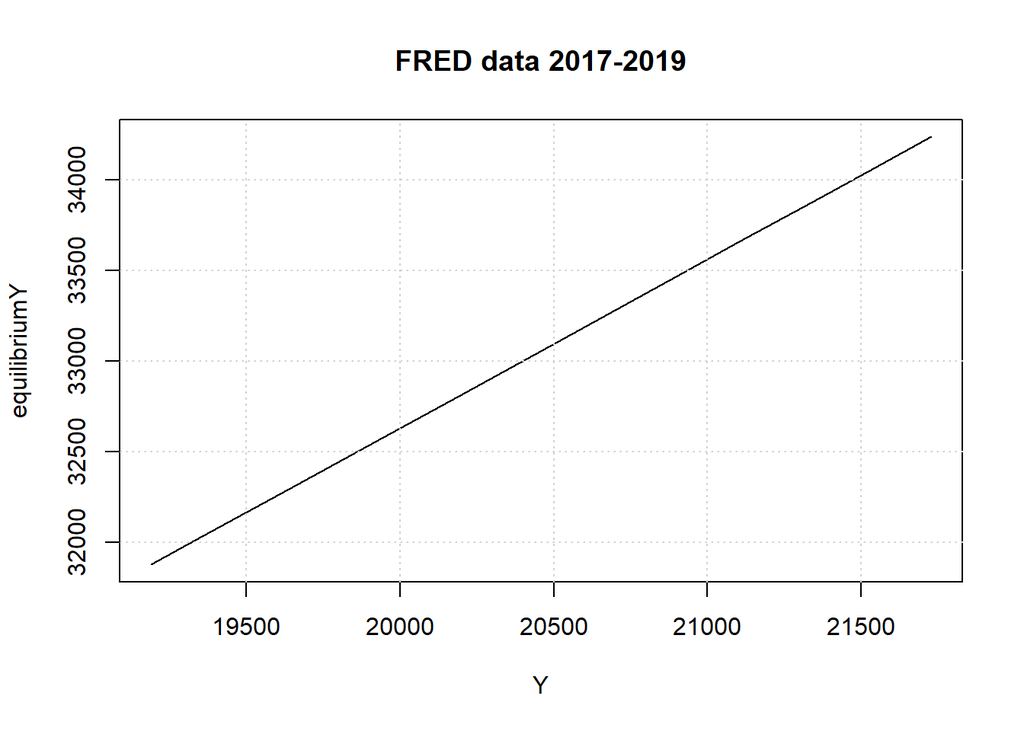

```r
equilibriumY = IS_Y( C0, b, I0, dY, dInt, equilibIntRate, Tax, g_Spend, netX)
plot(Y, equilibriumY, type='l',main='FRED data 2017-2019')
grid()
```

```r
GDP = C + I + g_Spend - netX
print(paste('national income accounting GDP: $', round(GDP)))
```

```
## [1] "national income accounting GDP: $ 25938"
```

### 2. using interest rate from IS above, find mOp to match intR. Keep GDP around $21700B

```r
# Monetary policy set money supply

LM_i(mOp,Y_FE, M0, m1, m2)
```

```
## [1] -1.49993
```

Write up your results; given the likely effects of COVOD19, what Econ policy recommendations are made by the IS-LM model?

Include your recommendations for: 1. Federal taxes- tax cut, increase federal taxes, of leave at curreint level? What is the dollar amound of taxes that best serves to make predicted GDP around $21700B 2. Money supply: what level makes the most sense to maintain interest around 1%? 3. Government spending: should government spending be increased, decreased or left at current levels? What dollar amount do you recommend for government spending

Do your recommedations seem reasonable, given this is an election year?